# Alliance ACO Progress Report

Northern Arizona Regional Behavioral Health Alliance Accountable Care Organization

Author

John Ryan Kivela, MA

Published

August 30, 2023

# Executive Summary

The Northern Arizona Regional Behavioral Health Alliance (NARBHA), hereafter “The Alliance”, is a collaborative project between The Narbha Institute (TNI) and Blue Cross Blue Shield of Arizona - Health Choice (BCBSAZ-HC). It is a first of its kind Behavioral Health Accountable Care Organization (ACO), specifically created to improve the health outcomes of disadvantaged people in rural Arizona. The focus of the Alliance is quality improvement and member satisfaction in our rural communities, as well as clinical advancement of our providers and program development of best practices.

This report outlines Alliance Provider performance, areas of strengths and focus, and plans for improvement and advancement. Overall, Alliance performance improved over the last month, increasing it’s level of performance above and beyond ALL the measure targets, including Follow Up After Hospitalization (FUH 7 Day), Anti-depressant Medication Management (AMM2), and Use of Opioids at High Dosage (HDO).

The Alliance continues to perform ABOVE the High Performance Target for Follow Up after Hospitalization!

# Enrollments

The Alliance, in close coordination with Health Choice, gathers member enrollment data from Health Choice databases, joining various data sources to compile a thorough and actionable active member roster. The roster is then distributed to each Alliance Provider by way of their respective Alliance Individualized Dashboards.

The Alliance serves 93121 people, as of 2023-08-25.

### Membership by County

There are no significant changes in the balance of members across the Northern Region) since the last reporting period. Mohave is the most densely populated, accounting for nearly 0.4896318 of the membership. Conversely, Apache is the least densely populated, accounting for 0.0489256 of the membership. The figures below further outline the geographical distribution of the Alliance ACO membership.

**Member Distribution by County**

2023-08-25

| County | Members | Percent |
| --- | --- | --- |
| Apache | 4,556 | 4.89 % |
| Coconino | 11,547 | 12.40 % |
| Mohave | 45,595 | 48.96 % |
| Navajo | 15,012 | 16.12 % |
| Yavapai | 16,411 | 17.62 % |

*SOURCE: BCBSAZ Global Members*

### Gender and Age

**Member Distribution by Sex**

2023-08-25

| Sex | Members | Percent |
| --- | --- | --- |
| Female | 48,422 | 52.00 % |
| Male | 44,232 | 47.50 % |
| NA | 467 | 0.50 % |

*SOURCE: BCBSAZ Global Members, extracted 08-25-2023*

## The figure below demonstrates age distributions of Alliance ACO members

The figure below demonstrates age distributions of Alliance ACO members.

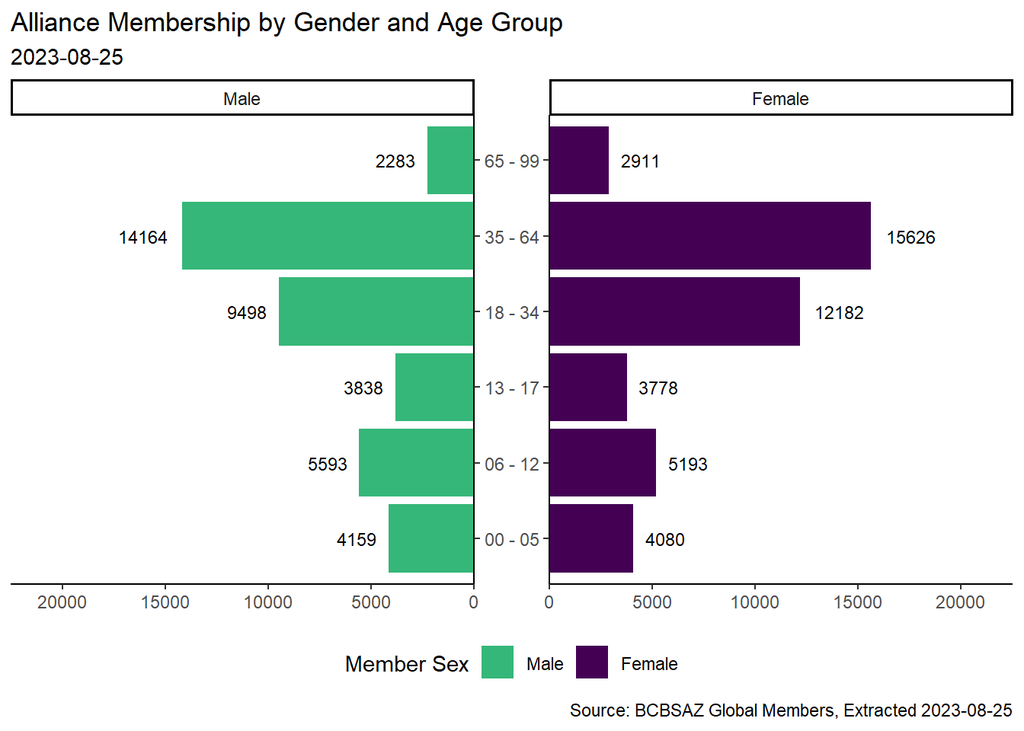

## Alliance Membership Allocation Information

Alliance Providers are assigned members at the beginning of each contract year. The Alliance supports member voice and choice, and as such provider assignment changes throughout the year in accordance with changing member needs and new enrollments. The following table describes the assignment by provider at the beginning of the contract year, and the current health plan auto-assignment by provider at the time of this reporting.

The *Alliance Allocation* represents the number of members for whom the providers are incentivised through the ACO. The *BCBSAZ Auto Assignment* represents the population of members for whose care the providers are responsible, and for whom they are measured.

We continue to monitor the impact of ending of the COVID19 public health emergency.

Alliance Provider Member Allocation

2023-08-25

| Provider | Alliance Allocation | BCBSAZ Auto Assignment | Percent Difference | Percent of Membership |
| --- | --- | --- | --- | --- |
| CBI | 7,732 | 7,066 | -8.61% | 7.56% |
| CPIH | 16,718 | 14,968 | -10.47% | 16.36% |
| LCBHC | 5,129 | 4,569 | -10.92% | 5.02% |
| MMHC | 33,025 | 30,252 | -8.40% | 32.31% |
| PH | 9,151 | 9,293 | 1.55% | 8.95% |
| SBHS | 17,175 | 15,033 | -12.47% | 16.80% |
| SHG | 5,910 | 5,436 | -8.02% | 5.78% |
| TGC | 7,377 | 6,504 | -11.83% | 7.22% |

*Alliance Allocation based on Contract Year 2022-2023*

# Performance Measurement

## HEDIS Measures

The goal of the Alliance is to improve the Effectiveness of Care in the ACO community. WE focus on the following three domains; Follow Up after Hospitalization (FUH), Anti-depressant Medication Management (AMM), and Use of Opioids at High Dosage (HDO).

## NCQA Performance Measures, HEDIS My2023

Alliance Performance Measures (NCQA)

2023-08-25

| Domain | Measure | NCQA_Mean |
| --- | --- | --- |
| Behavioral Health | Antidepressant Medication (AMM), Effective Acute Phase Treatment | 57.29% |
| Behavioral Health | Follow-Up After Hospitalization for Mental Illness (FUH), Follow-Up Within 7 Days Post-Discharge | 39.36% |
| Behavioral Health | Follow-Up After Emergency Department Visit for Mental Illness (FUM). Not required by Contract | 40.00% |
| Overuse/Approrpiateness | Use of Opioids at High Dosage (HDO) | 93.00% |

## Provider Performance

### All Alliance Performance

In order to report performance of the dependent variable, the Alliance Progress Report utilizes the VBP Validation Model [^1] data set. The monthly table *VBPQR_AllApsCombined_Cleaned_complete* is imported and transformed to summarize the aggregation for the individual providers and the entire Alliance ACO network.

Overall Performance of Alliance Provider Network

2023-08-23

| NCQA Measure | Compliant | Eligible | Percent Compliant | NCQA Mean | Performance Level |
| --- | --- | --- | --- | --- | --- |
| AMM | 1050 | 1643 | 63.91% | 57.29% | +6.62% |
| FUH | 273 | 572 | 47.73% | 39.36% | +8.37% |
| FUM | 57 | 206 | 27.67% | 40.10% | −12.43% |
| HDO | 2455 | 2603 | 94.31% | 93.00% | +1.31% |

*SOURCE: BCBSAZ VBP Performance Reports, Claims Adjudicated Through 2023-07-31* *FUM not required by contract*

**Alliance Performance Levels**

- AMM: The overall performance score for AMM was 0.6390749 (0.0661749)
- FUH: The overall performance score for FUH was 0.4772727(0.0836727)
- HDO: The overall score for HDO was 0.9431425(0.0131425)

The figure below demonstrates The Alliance performance scores.

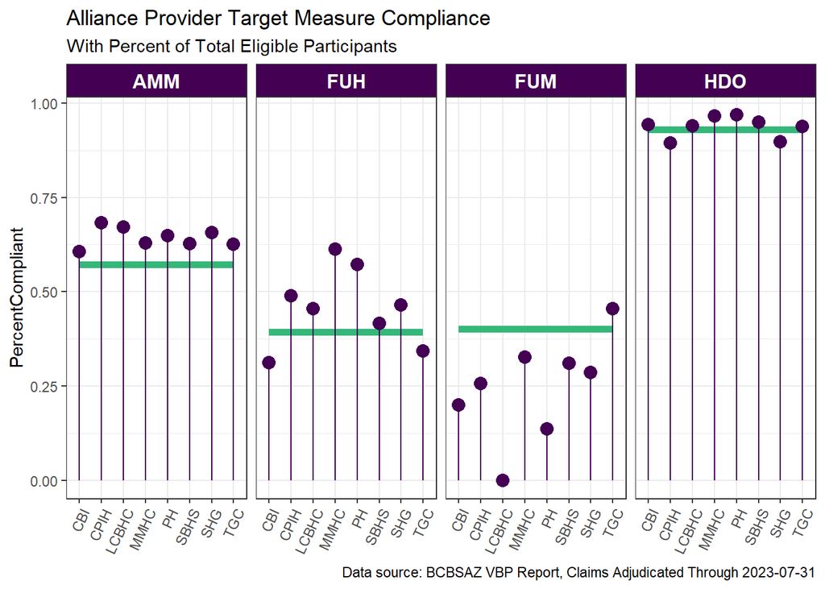

### A Closer Look

#### Antidepressant Medication Management (AMM)

Performance of Alliance Provider Network (AMM)

2023-08-23 NCQA Mean = 57.29%

| Provider | Eligible | Compliant | Percent Compliant | Performance Level |
| --- | --- | --- | --- | --- |
| Provider_ShortName |  |  |  |  |
| CBI | 180 | 109 | 60.56% | +3.27% |
| CPIH | 249 | 170 | 68.27% | +10.98% |
| LCBHC | 64 | 43 | 67.19% | +9.90% |
| MMHC | 351 | 221 | 62.96% | +5.67% |
| PH | 165 | 107 | 64.85% | +7.56% |
| SBHS | 426 | 267 | 62.68% | +5.39% |
| SHG | 96 | 63 | 65.62% | +8.34% |
| TGC | 112 | 70 | 62.50% | +5.21% |

*SOURCE: BCBSAZ VBP Quality Roster, Claims Adjudicated Through 2023-7-31*

#### Follow Up After Hospitalization (FUH)

Performance of Alliance Provider Network (FUH)

2023-08-23 NCQA Mean = 39.36%

| Provider | Eligible | Compliant | Percent Compliant | Performance Level |
| --- | --- | --- | --- | --- |
| Provider_ShortName |  |  |  |  |
| CBI | 32 | 10 | 31.25% | −8.11% |
| CPIH | 92 | 45 | 48.91% | +9.55% |
| LCBHC | 22 | 10 | 45.45% | +6.09% |
| MMHC | 111 | 68 | 61.26% | +21.90% |
| PH | 63 | 36 | 57.14% | +17.78% |
| SBHS | 192 | 80 | 41.67% | +2.31% |
| SHG | 28 | 13 | 46.43% | +7.07% |
| TGC | 32 | 11 | 34.38% | −4.99% |

*SOURCE: BCBSAZ VBP Quality Roster, Claims Adjudicated Through 2023-07-31*

#### Use of Opioids at High Dosage (HDO)

Performance of Alliance Provider Network (HDO)

2023-08-23 NCQA Mean = 93.00%

| Provider | Eligible | Compliant | Percent Compliant | Performance Level |
| --- | --- | --- | --- | --- |
| Provider_ShortName |  |  |  |  |
| CBI | 190 | 179 | 94.21% | +1.21% |
| CPIH | 412 | 368 | 89.32% | −3.68% |
| LCBHC | 147 | 138 | 93.88% | +0.88% |
| MMHC | 738 | 713 | 96.61% | +3.61% |
| PH | 218 | 211 | 96.79% | +3.79% |
| SBHS | 687 | 652 | 94.91% | +1.91% |
| SHG | 98 | 88 | 89.80% | −3.20% |
| TGC | 113 | 106 | 93.81% | +0.81% |

*SOURCE: BCBSAZ VBP Quality Roster, Claims Adjudicated Through 2023-07-31*

## Footnotes

[^1]: Kivela, John Ryan. (2023). Value Based Purchasing Validation Model. The Alliance ACO.